# Posa

lzarauz & mkorta

1/2/2021

# 1 Objetivo

En este codigo vamos a comparar los datos de muestreo, ventas y N1V. El objetivo de ver la magnitud de los desembarcos que se llevan a POSA, si están incluidos en las hojas de venta de la OPPAO y si los observamos en el muestreo.

# 2 Resumen

Los pesos observados en los muestreos y los pesos de ventas se ajustan bastante bien, tanto en bakas como en parejas. De esta manera, parece comprobado que el muestreador accede a lo que se registra en la hoja de la OPPAO que no tiene encuentra POSA.

Lo enviado a POSA no lo estamos muestreando. Si miramos lo declarado por POSA en lso pdf, para las parejas son muy pocos Kg. En las bakas nos estamso perdiendo una parte de capturas de merluza, fanecas y gallos, y quiza triglidos.

Hasta ahora siempre hemos asumido que se declaran mayores desembarcos en Ventas que en N1V. esto se confirma en las parejas, pero no en las bacas (y eso es raro):

- **Parejas 8abd**: la merluza muestra algo de “underreporting”. También rapes, rayas, pintaroja y congrio (que son pocos kilos). Para chicharros y gallos el peso es mayor en N1V.
- **Parejas de litoral**: gallos y verdel se suman a la lista de “underreporting”.
- **Bakas**: en general están bastate ajustados los pesos de N1V y Ventas pero hay un sesgo por barco. Sobresale el Kalamendi que declara mas en NV que en Ventas.

**Puntos que necesitamso aclarar**:

- Por qué lo declarado por POSA en los pdf (POSA-Ventas) es menor que lo delcarado en POSA-N1V? Los datos de POSA-Ventas son completos? puede que no sfalte algo de las parejas? quien rellena las N1V? comprador o vendedor?
- Preguntar en POSA a ver si nos pueden pasar los ficheros como texto par apoder importarlos en la BD

# 3 Anáslisis y resultados

## 3.1 Datos

### 3.1.1 Fuentes de datos

Tenemos tres fuentes de datos de venta para la flota de arrastre de Ondarroa:

- N1V: Las Notas de Venta oficiales (proprcionadas por HAZI). Estas NV incluyen tanto lo que va a POSA, como lo adquirido por otros compradores.
- Ventas: Las hojas de la OPPAO que nos proporcionan los armadores. A estas hojas de venta añadimos las notas que nos pasa POSA en pdf.
- Muestreo en puerto: los datos que recogen los muestreadores (tallas y peso desembarcado)

### 3.1.2 Procesados

Se cargan los ficheros de Ventas, N1V y Muestreos (Tallas) por un lado y por otro los maestros de Especies y Buques. En un primer paso se filtran en todos los ficheros la flota de Ondarroa: parejas (8abd) “PTB_DEF_>=70_0_0”, parejas de litoral “PTB_MPD_>=55_0_0” y las bacas (8abd) “OTB_DEF_>=70_0_0”.

Se unifica con un código lo que identificamos que procede de POSA y lo que no, en los ficheros de N1V y Ventas. En Muestreos no lo sabemos con segurdad, pero rellenamos el campo como “no POSA”.

Debido a que para el año 2020 tenemos una introducción de datos incompleta (datos de la OPPAO: introducidos de enero a octubre, datos de POSA introducidos hasta Junio; N1V: completo; Tallas: completo) se eliminan los meses incompletos para que los datos sean comparables. El ejercicio se realizará con el primer semestre del año 2020.

Para que los pesos de N1V, Ventas y Muestreos sean equivalentes se agregan las capturas de ambos barcos en las parejas. Esto es así, porque en la base de datos los desembarcos de las parejas se asignana al 50% a cada buque que comforman la pareja.

Se unen las tres tablas (N1V, Ventas y Muestreo) previamente habiendolas agregado por “IdVenta”, “Especie” y “Posa (sí/no)” para obter el sumatorio de los Pesos. Se unifican corrijen y unifican tmabién los nombres de las especies entre las tablas. Finalmente se agrega a la tabla “nombre de buque”, “Mes”, “Día”, “Año” y “Metier”. Convertimos NA en ceros, para el peso OPPAO y el peso NV.

## 3.2 Tablas

### 3.2.1 Tabla por especie: POSA

En tabla esta mostramos los pesos totales (kg) por especie para cada fuente de datos: Ventas-POSA, Ventas-NoPOSA, N1V-POSA, N1V-POSA. Podemos filtrar qué especies se desembarcan en Ventas y no en N1V, ya la inversa.

|  | Nombre.Oficial | Nombre.corregido | Ventas_noPOSA | Ventas_POSA | Ventas.Total | Ventas.prop.POSA | NV_noPOSA | NV_POSA | NV.Total | NV.prop.POSA |
| --- | --- | --- | --- | --- | --- | --- | --- | --- | --- | --- |
| 1 | Abadejo | Abadejo | 578 | 0 | 578 | 0% | 364 | 0 | 364 | 0% |
| 2 | Acedia | Soleidos | 2075 | 0 | 2075 | 0% | 10513 | 0 | 10513 | 0% |
| 3 | Aligote | Esparidos | 0 | 0 | 0 |  | 36 | 0 | 36 | 0% |
| 4 | Bacalao | Bacalao | 1012 | 0 | 1012 | 0% | 2078 | 0 | 2078 | 0% |
| 5 | Bejel | Triglidos | 2031 | 0 | 2031 | 0% | 0 | 0 | 0 |  |
| 6 | Boga | Esparidos | 90 | 0 | 90 | 0% | 133 | 0 | 133 | 0% |
| 7 | Breca | Breca | 0 | 0 | 0 |  | 58 | 0 | 58 | 0% |
| 8 | Brotola de fango (Phycis blennoides) | Brotola de fango | 41655 | 5 | 41660 | 0% | 37774 | 2534 | 40308 | 6% |
| 9 | Buey | Buey | 248 | 0 | 248 | 0% | 975 | 0 | 975 | 0% |
| 10 | Cabra (Helicolenus dactylopterus) | Cabra | 24432 | 6167 | 30599 | 20% | 23080 | 7388 | 30468 | 24% |

[output cut: 91 more lines]

## 3.3 Figuras

### 3.3.1 Peso Muestreo vs Peso ventas por marea (no incluye POSA)

La relación entre los pesos observados en los muestreos, y las pesos de ventas se ajustan bastante bien, salvo algunos puntos que hemos identificado para revisar. De esta manera, parece comprobado que el muestreador accede a lo que se registra en la hoja de la OPPAO que no tiene encuentra POSA. Estos se da en ambos metier.

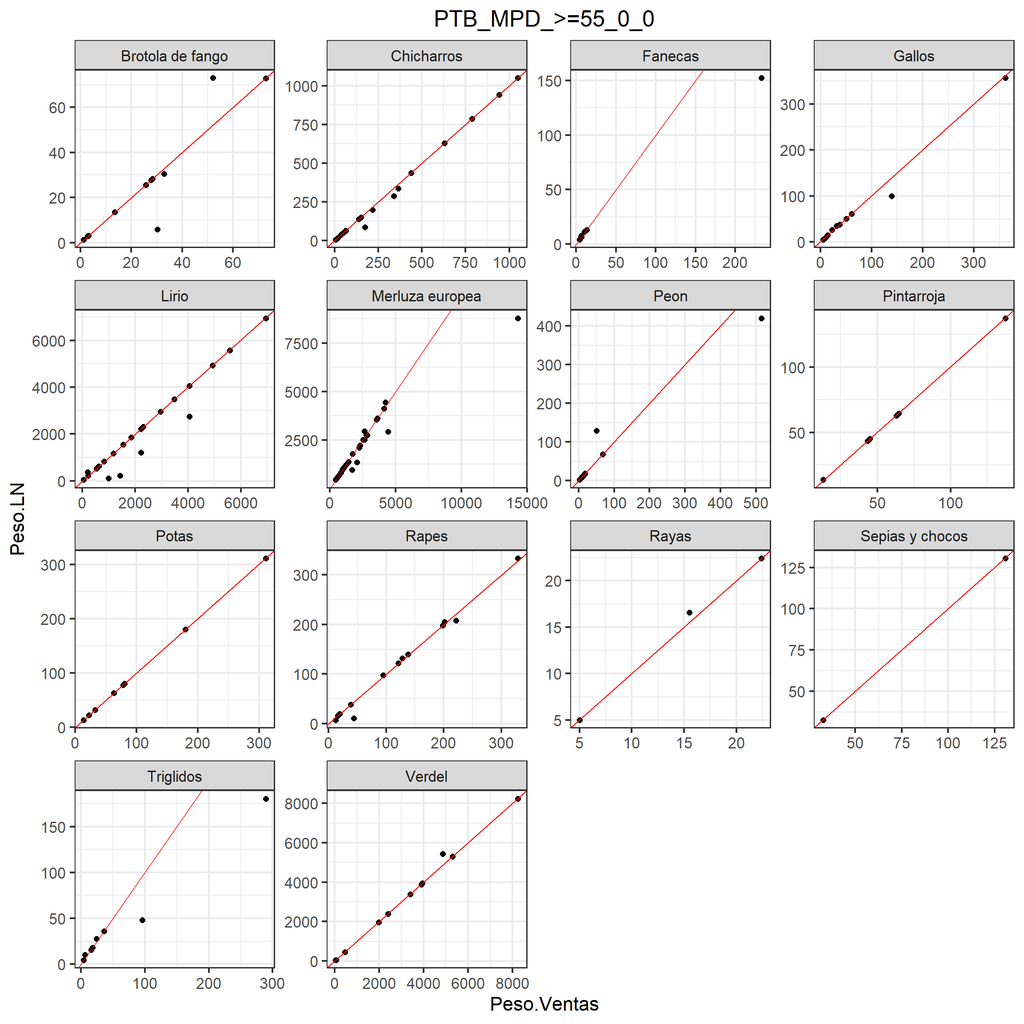

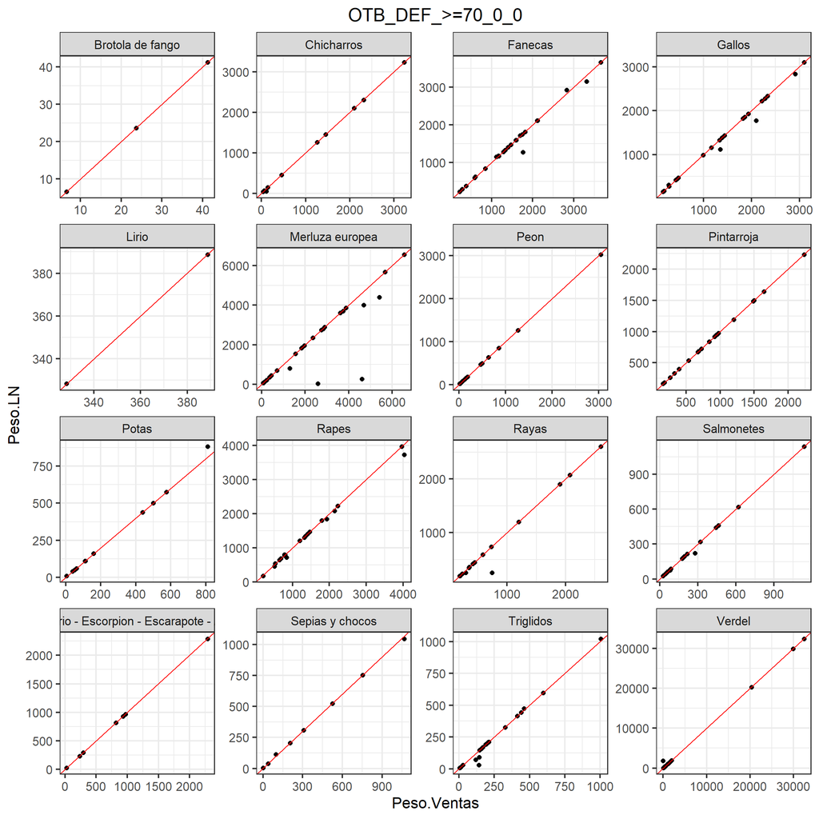

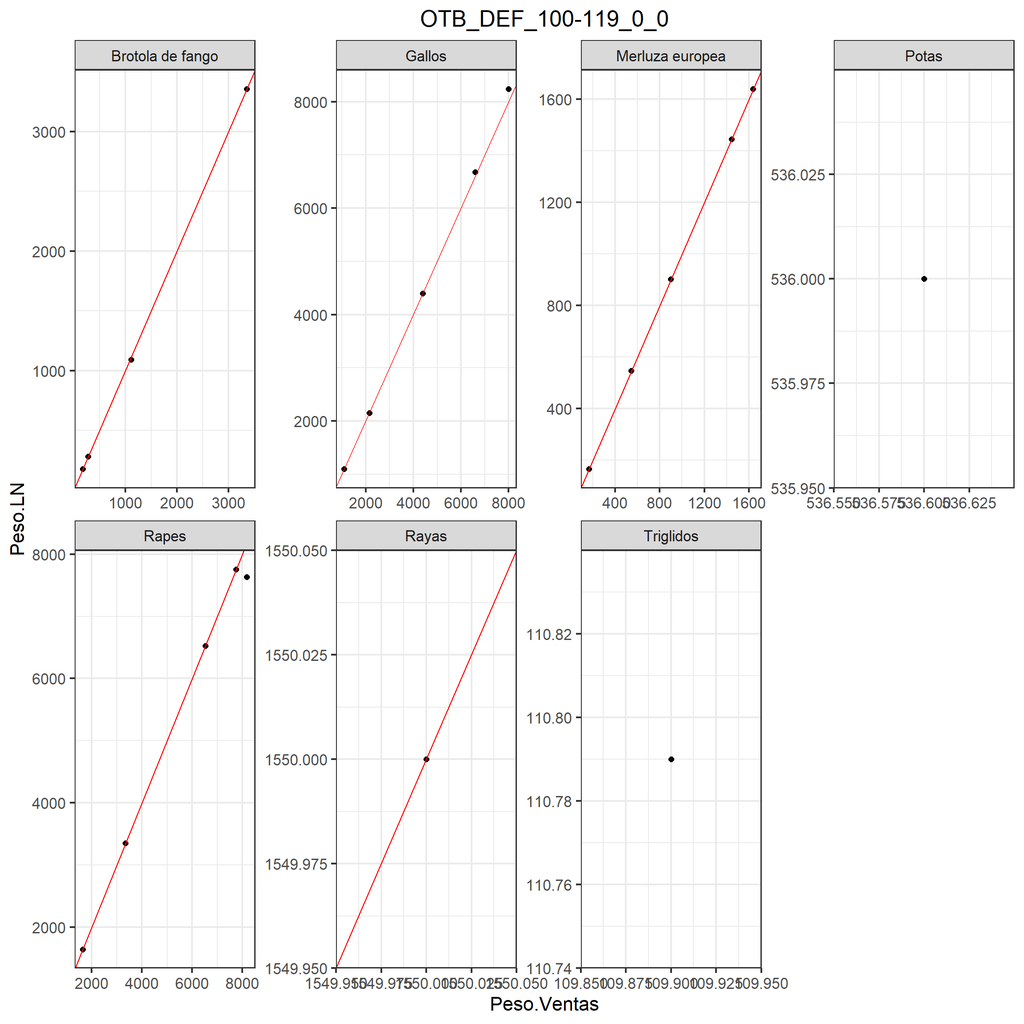

### 3.3.2 Peso Muestreo vs Peso ventas por marea (incluye POSA)

Al añadir POSA, en PTB no cambia mucho debido a que hay muy poca POSA declarada en Ventas, aunque si se observan algunos meses con más desembarcos en Ventas para verdel y lirio. En OTB se observa que en general el peso Venta es mayor que el peso Muestreado, particularmente en merluza, fanecas y gallos. Estas especies son de las que nos estaríamos perdiendo parte de sus desembarcos porque se llevan a POSA y el muestreaor no tiene acceso a ellos.

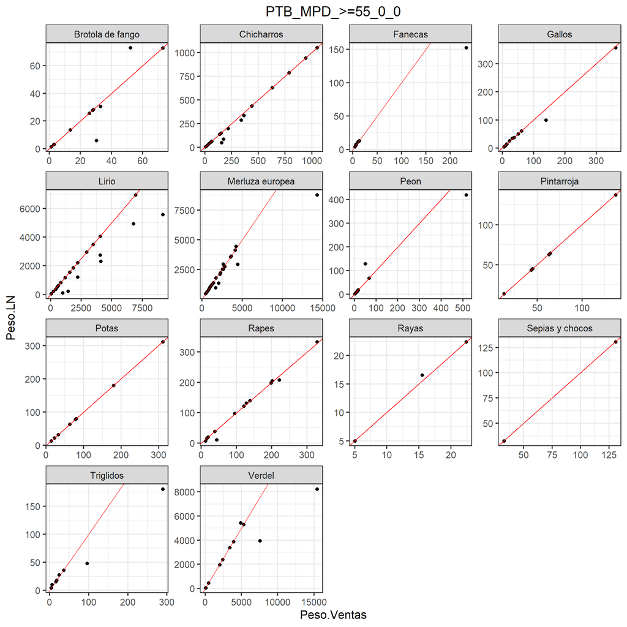

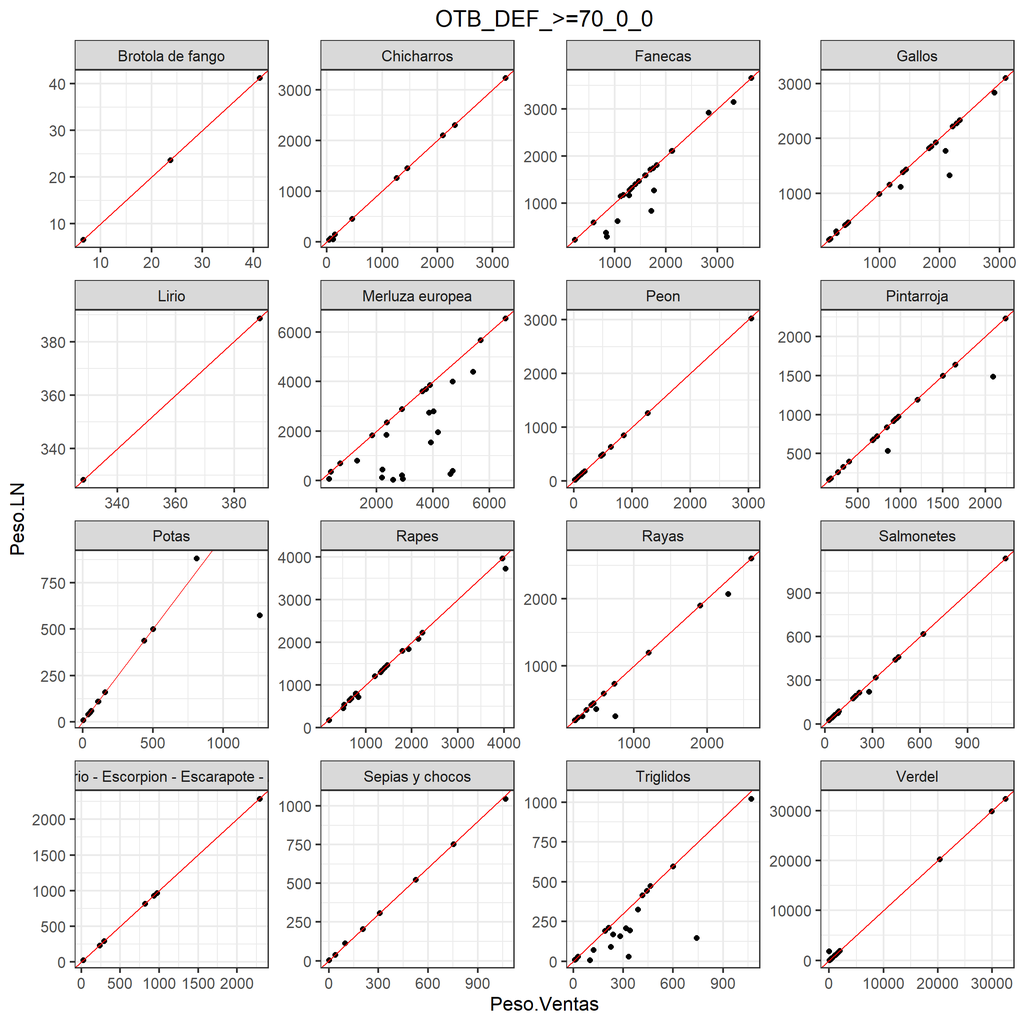

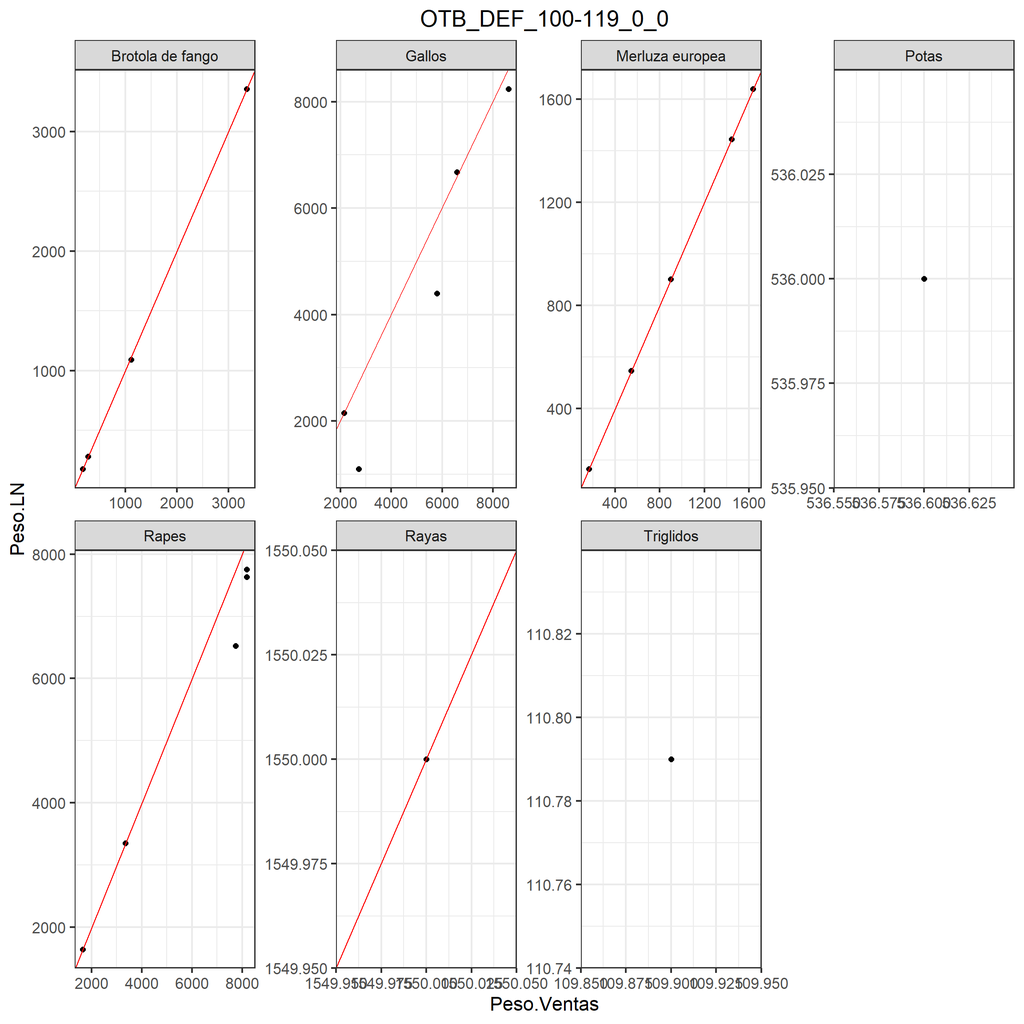

### 3.3.3 Peso NV vs Peso ventas por mes y por barco (incluye POSA)

Parejas 8abd: muestran underreporting" la merluza, rapes, rayas, pintaroja y congrio (que son pocos kilos). Para chicharros y gallos el peso es mayor en N1V.

Parejas de litoral: gallos, verdel y pulpos se suman a la lista de “underreporting”

Bakas: en general están bastate ajustados los pesos de N1V y Ventas pero hay un sesgo por barco. Sobresale el Kalamendi que declara mas en NV que en Ventas.

Hasta ahora siempre hemos asumido que se declaran mayores desembarcos en OPPAO que en N1V. esto se confirma en las parejas, pero no en las bacas (y eso es raro).

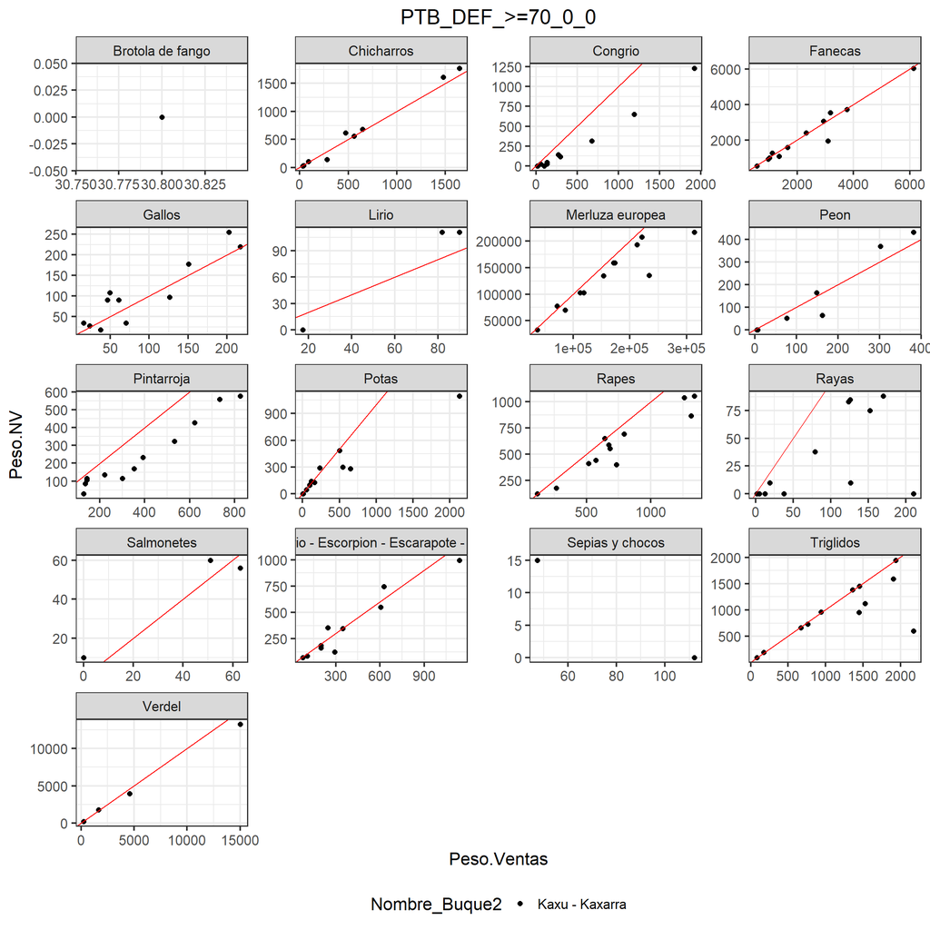

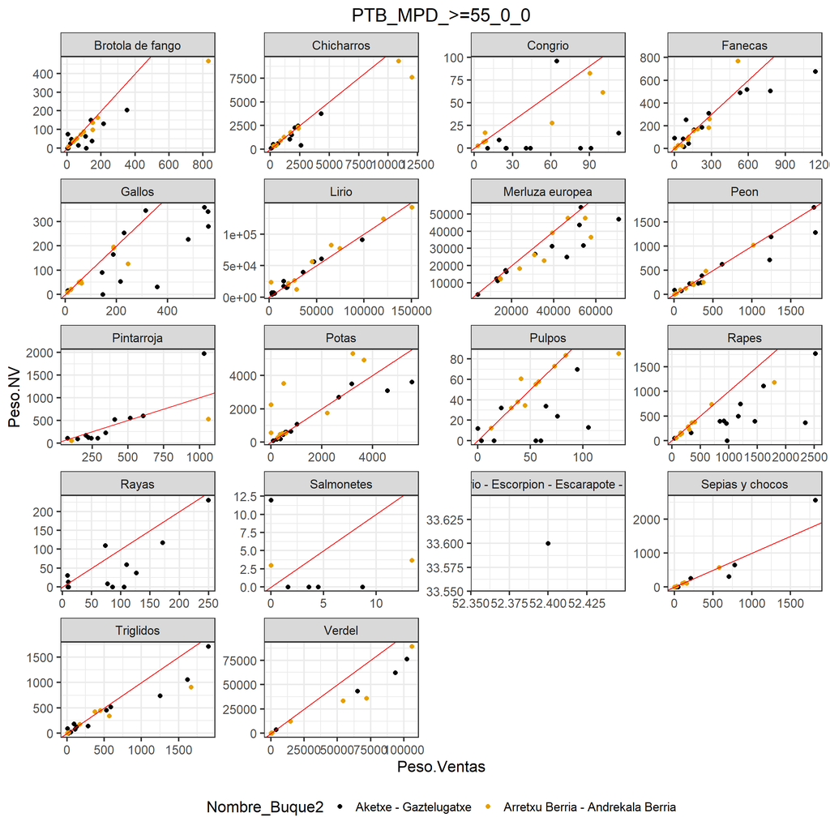

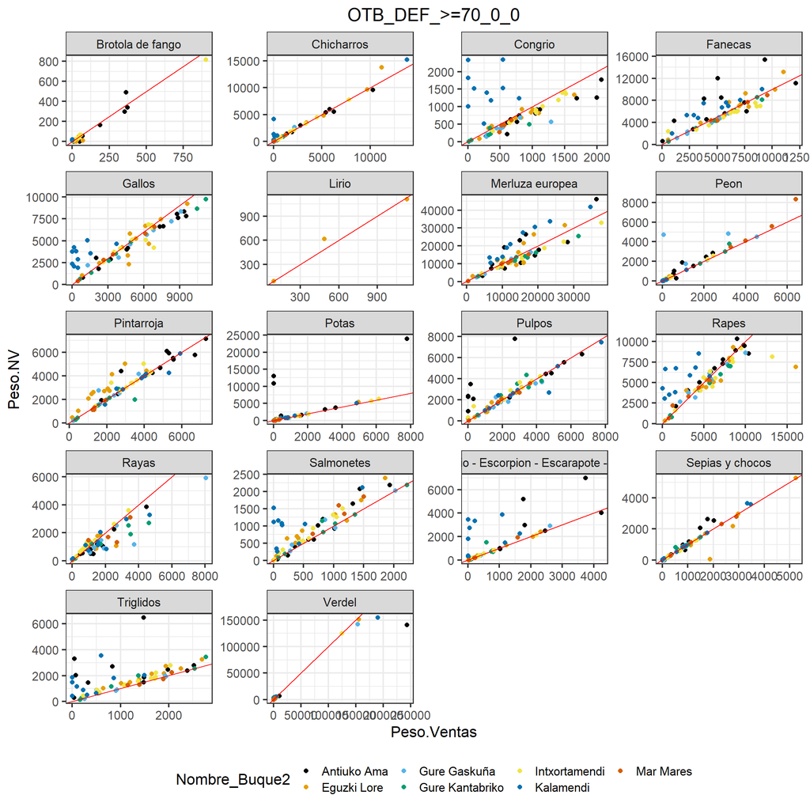

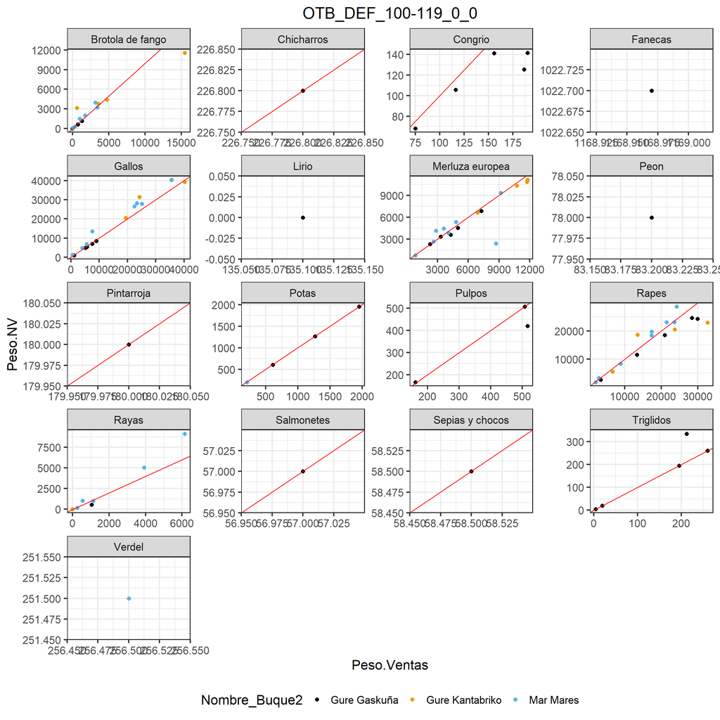

### 3.3.4 Peso NV vs Peso ventas por mes y separando POSA y no POSA

Parejas 8abd: no se declara ningun kg en Ventas-POSA (los pdf), sin embargo, en N1V sí que se declara merlzua.

Parejas litoral: se declara más merluza en N1V-Posa que en ventas

Bakas: los pesos POSA declarados en N1V y Ventan se ajustan mejor.

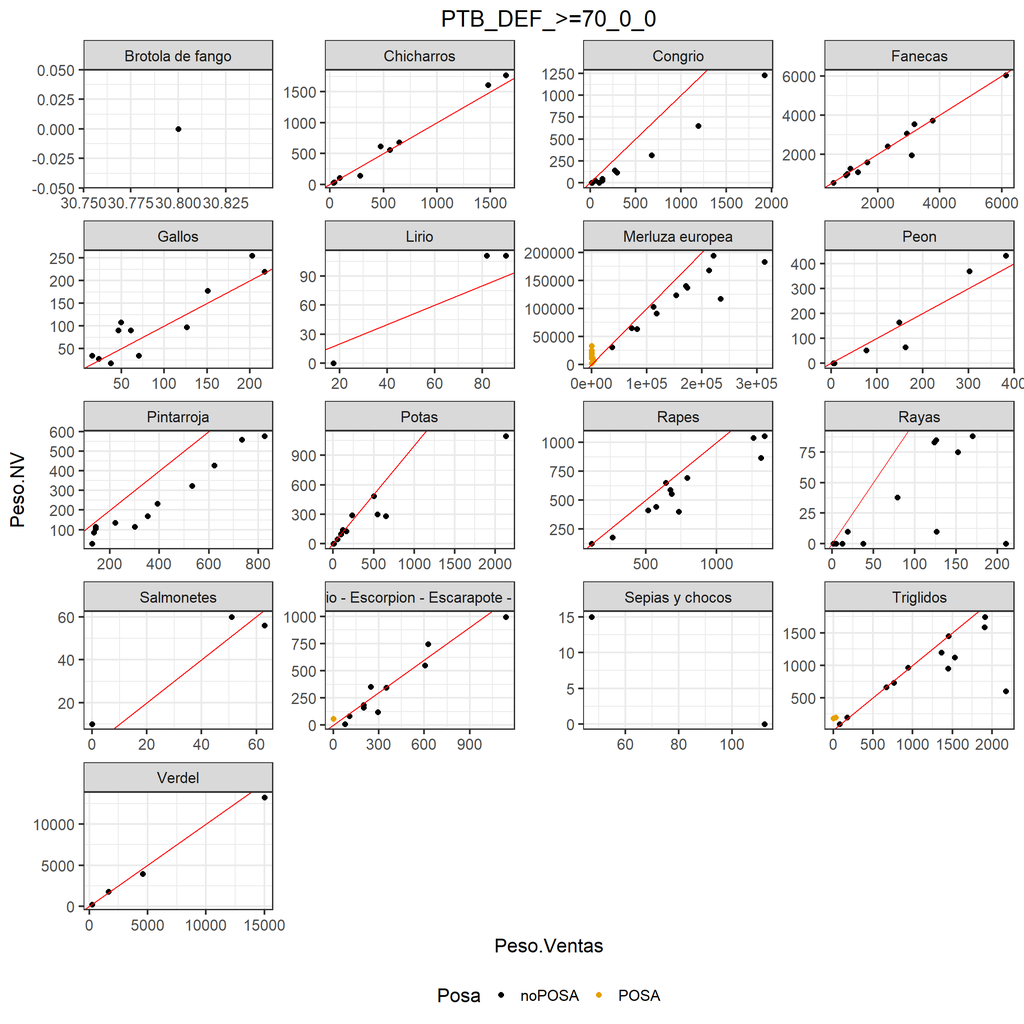

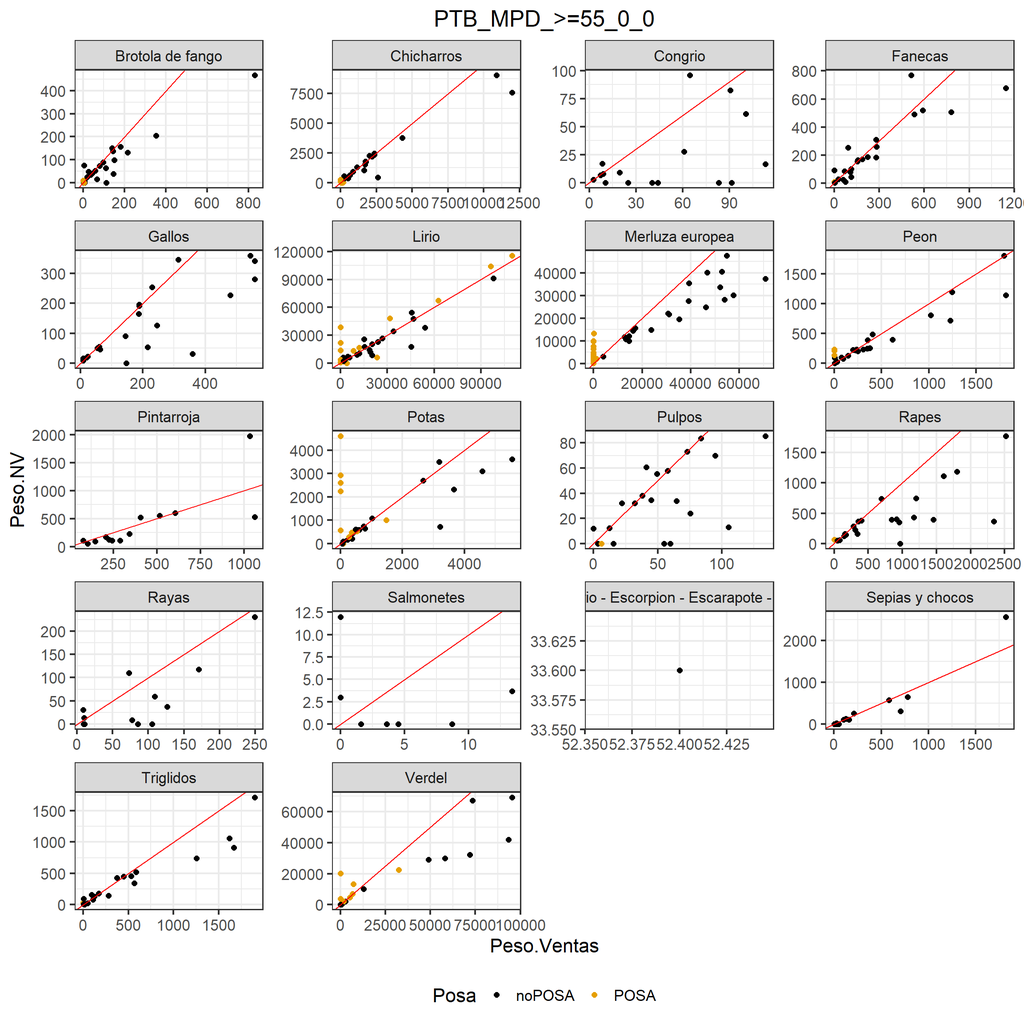

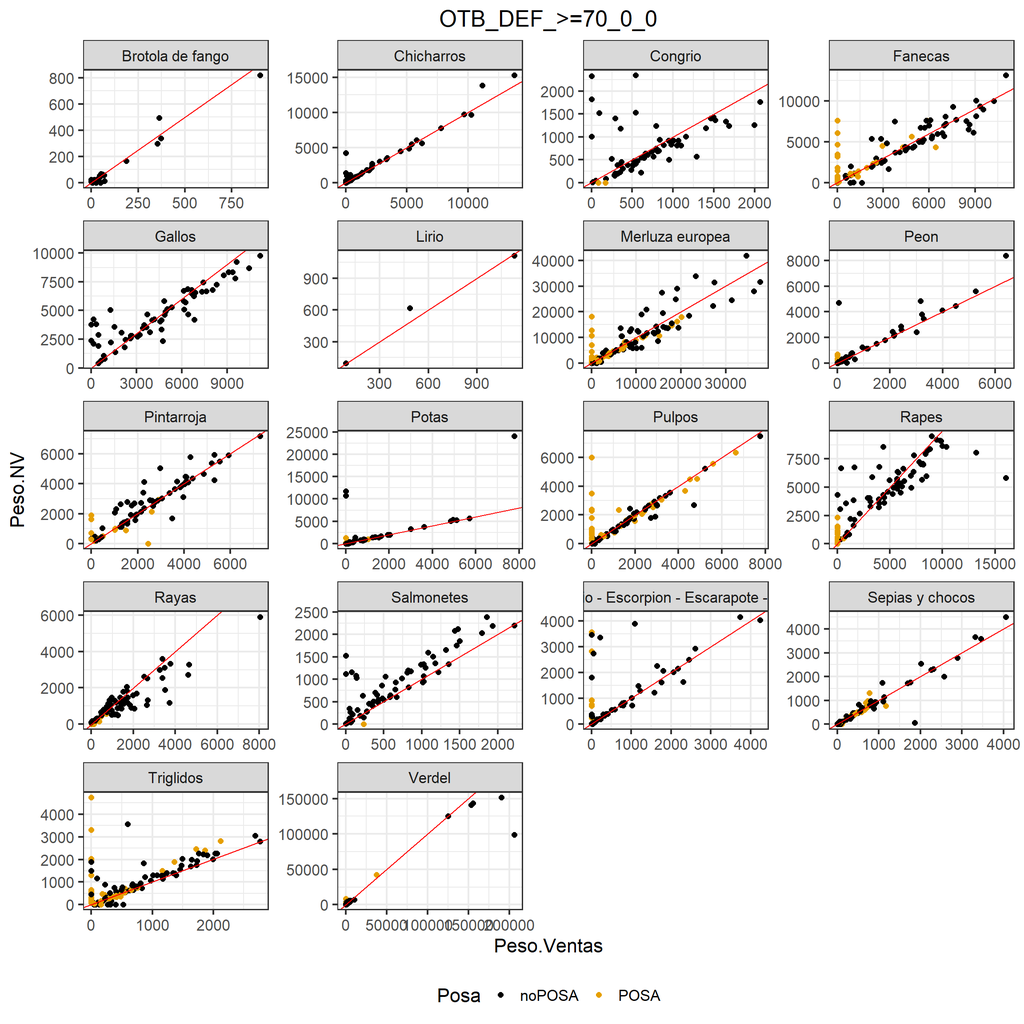

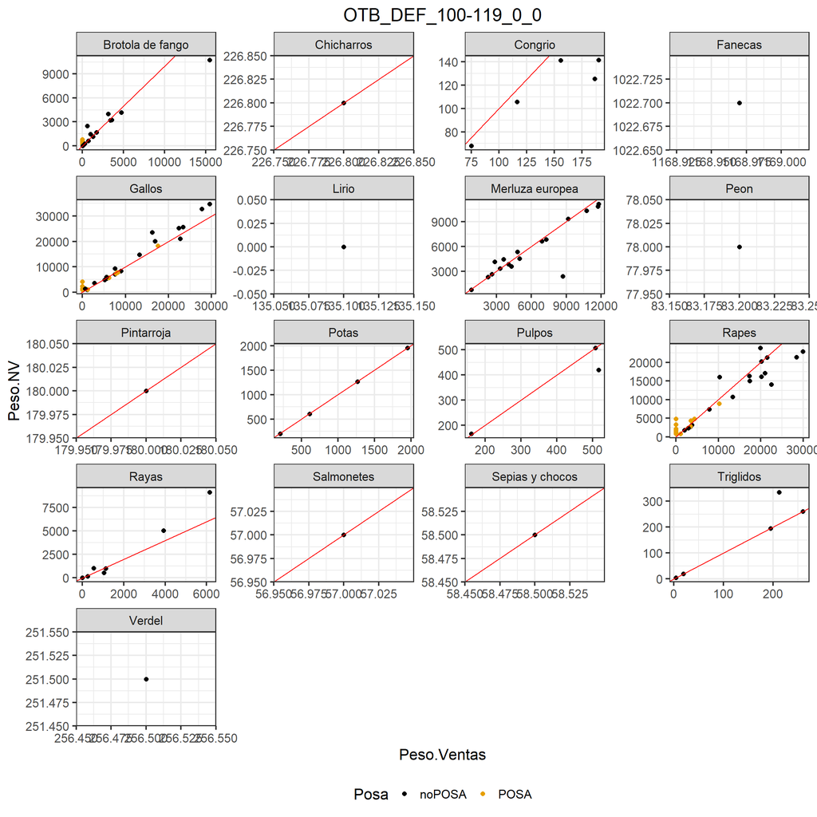